# Analyse des besoins non satisfaits en planification familiale en République Démocratique du Congo (RDC)

Mbiya-Ngandu Luboya Henri

2025-08-19

# **Introduction**

## Contexte

La République Démocratique du Congo (RDC) est l’un des pays d’Afrique subsaharienne où les indicateurs de santé reproductive restent préoccupants. Malgré les efforts du gouvernement et de ses partenaires, l’accès aux services de planification familiale demeure limité, surtout en milieu rural.

Le taux de fécondité élevé et les besoins non satisfaits en contraception **(BNS)** soulignent l’urgence d’interventions ciblées.

## Objectifs de l’étude

### Objectif général

Estimer les proportions de besoins non satisfaits en planification familiale (BNS) selon les caractéristiques sociodémographiques des femmes en âge de procréer en RDC.

### Objectifs spécifiques

- La province
- Le niveau d’éducation
- Le milieu de résidence
- La tranche d’âge,

# **Méthodologie**

### Source de données

La source des données est l’Enquête Démographique et de Santé (EDS ) réalisée en RDC entre les années 2013 et 2014

| Variables d'interêt dans EDS | Descriptif |
| --- | --- |
| caseid | ID du repondant |
| v010 | Année de naisance |
| v012 | Age du repondat |
| v024 | Province du repondnat |
| v025 | Milieu de résidence |
| v106 | Niveau d'étude |
| v626a | Satisfaction des besoins en PF |
| v313 | Methode PF actuellment utilisée |
| v501 | Statut marital |
| v502 | Statut actuel par rapport à une union |

[output cut: 2 more lines]

#### Nettoyage & recodage

Après chargement des données nous allons procéder aux différentes opérations de nettoyage et préparation du jeux des données.

### Variables clés

- satisfaction_besoin (variable cible)
- poids_echantillon (pondération)
- Variables explicatives : âge, province, niveau d’étude, milieu de résidence, statut marital, statut d’union

### Population cible

La population cible de notre étude est l’ensemble des Femmes fécondes en union et en âge de procréer. Ceci implique que les femmesn en age de procréer mais qui ne sont pas en union et celles présentatn des difficulté de fécondité seront exclues de notre étude.

### Analyses statistiques

- **Statistiques descriptives pondérées (Pondération & plan d’échantillonnage):**

**Objectif** : préparer les *poids* et déclarer un *design survey*.

- **Estimations (globales & désagrégées)**

**Objectif** : calculer la proportion de BNS (avec IC95%) *globalement* et par **province**, **milieu**, **niveau d’étude**, **groupe d’âge**.

- **Visualisation des proportions**

  **Objectif** : barplots (avec barres d’erreur IC95%) par province, milieu, niveau d’étude et âge.

#### **1- Analyse globale des besoins non satisfaits en RDC**

[output not shown]

#### **2- Analyse des besoins non satisfaits par province**

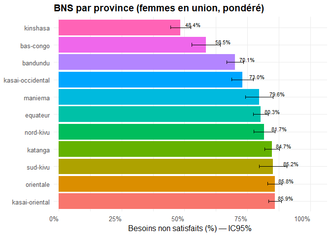

Nous constatons une forte hétérogénéité entre provinces : certaines présentent des taux très élevés (indiquant une demande contraceptive non satisfaite importante: Kasai-Oriental, Oriental, Su-Kivu), d’autres des taux faibles (meilleure couverture: Kinshasa, Bas-Congo).

#### **3- Analyse des besoins non satisfaits par rapport au milieu de résidence**

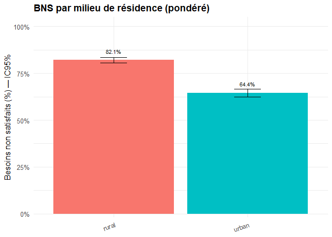

Cette analyse vient confirmer le fait que généralement, le BNS est **plus élevé en milieu rural** (accès plus limité aux services, contraintes culturelles, moins d’éducation sexuelle). En milieu urbain, le taux peut être plus bas mais parfois hétérogène selon les quartiers.

#### **4- Analyse des besoins non satisfaits par rapport niveau d’étude**

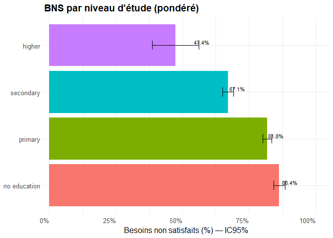

Nous remarquons que le BNS tend à **diminuer avec le niveau d’étude** : les femmes plus instruites ont souvent un meilleur accès à l’information et aux méthodes contraceptives, ainsi qu’une plus grande autonomie décisionnelle.

#### **5- Analyse des besoins non satisfaits par rapport aux groupes d’age**

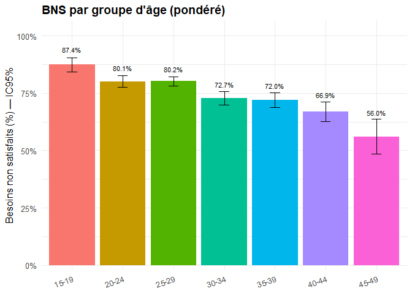

Cette tendance illustre la **complexité des besoins contraceptifs selon le cycle de vie**

# **Conclusion**

Les analyses réalisées mettent en évidence des **disparités significatives** dans la distribution des **besoins non satisfaits (BNS)** parmi les femmes en union, selon différents déterminants socio-démographiques et contextuels. Ces disparités traduisent des **inégalités d’accès à la planification familiale** et, plus largement, des différences dans l’autonomisation reproductive des femmes.

Les résultats indiquent que la **réduction des besoins non satisfaits** en planification familiale ne peut être obtenue sans une **approche multisectorielle et équitable**, agissant simultanément sur :

- L’**offre** (disponibilité, qualité, proximité des services),
- La **demande** (information, autonomisation, changement de normes sociales),
- Les **déterminants structurels** (éducation, pauvreté, inégalités territoriales).

En somme, **le BNS est un indicateur intégrateur** du développement social et de l’équité en santé

# **Reference**

- [R Graph courses: Data & AI training for health and life sciences](https://thegraphcourses.org/)
- [The DHS Program: Demographic and Health Surveys](https://dhsprogram.com/)